# Statistiques APAAD - 10/05/2020

## 6.4 Distribution des durées de clampage du cordon

| Durée de clampage | Nombre | Proportion |
| --- | --- | --- |
| plus de 3 minutes | 460 | 50.61 % |
| Après la délivrance | 438 | 48.18 % |
| moins de 3 minutes | 11 | 1.21 % |

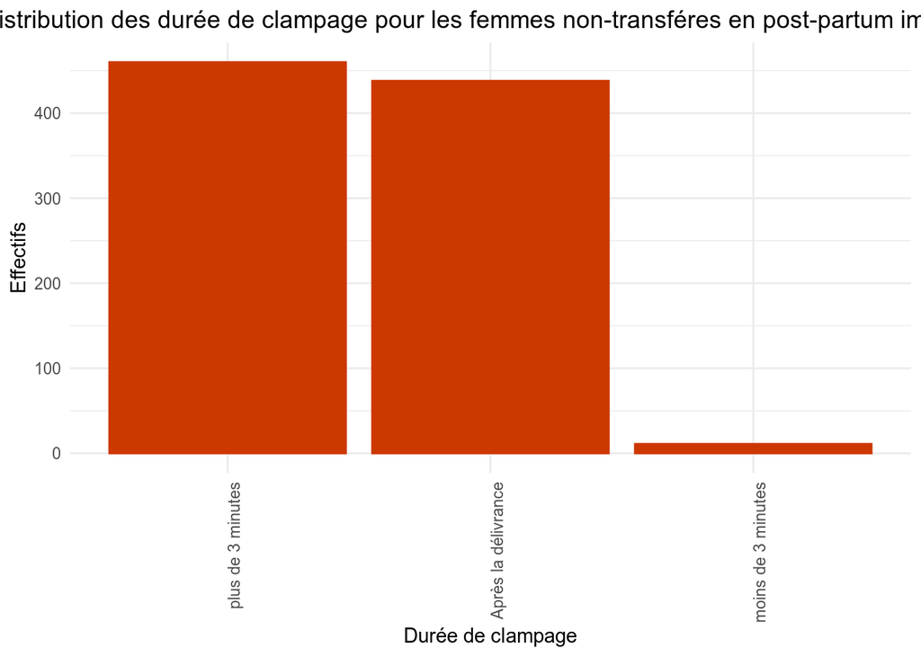

## 6.5 État du périnée

### 6.5.1 Distribution

| État du périnée | Nombre | Proportion |
| --- | --- | --- |
| Intact | 602 | 66.23 % |
| 1° degré : peau, muqueuse vaginale | 247 | 27.17 % |
| 2° degré : peau, muqueuse vaginale, muscles périnéaux | 57 | 6.27 % |
| Épisiotomie | 3 | 0.33 % |

[figure not shown]

### 6.5.2 Liaison entre état du périnée et âge de la mère / Parité / Poids du bébé / Hands on-off

On effectue une régression logistique où la variable à expliquer est l’état du périnée (1 : intact / 0 : degré 1 ou degré 2 ou épisiotomie), et les variables explicatives sont celles listées ci-dessus.

```
##
## Call:
## glm(formula = perinee ~ age_mere + parite + poids + hands_accouchement,
##     family = "binomial", data = don_perinee_age_)
##
## Deviance Residuals:
##     Min       1Q   Median       3Q      Max
## -2.2259  -1.2471   0.7187   0.9472   1.4569
##
## Coefficients:
##                              Estimate Std. Error z value        Pr(>|z|)
## (Intercept)                 1.9566704  0.8127127   2.408        0.016059 *
## age_mere                   -0.0077381  0.0173955  -0.445        0.656439
## parite                      0.5701778  0.0850302   6.706 0.0000000000201 ***
## poids                      -0.0006553  0.0001856  -3.530        0.000415 ***
## hands_accouchementHands on  0.0522208  0.2271378   0.230        0.818163
## ---
## Signif. codes:  0 '***' 0.001 '**' 0.01 '*' 0.05 '.' 0.1 ' ' 1
##
## (Dispersion parameter for binomial family taken to be 1)
##
##     Null deviance: 1135.9  on 887  degrees of freedom
## Residual deviance: 1068.5  on 883  degrees of freedom
## AIC: 1078.5
##
## Number of Fisher Scoring iterations: 4
```

Les résidus présentent une symétrie correcte. On effectue un test de vraissemblance (LRT) pour estimer la significativité statistiques des variables explicatives car ce test est plus robuste que le test de Wald dont les résultats sont disponibles ci-dessus.

```
## Analysis of Deviance Table
##
## Model: binomial, link: logit
##
## Response: perinee
##
## Terms added sequentially (first to last)
##
##
##                    Df Deviance Resid. Df Resid. Dev          Pr(>Chi)
## NULL                                 887     1135.9
## age_mere            1    5.271       886     1130.6         0.0216885 *
## parite              1   49.468       885     1081.2 0.000000000002017 ***
## poids               1   12.651       884     1068.5         0.0003755 ***
## hands_accouchement  1    0.053       883     1068.5         0.8179125
## ---
## Signif. codes:  0 '***' 0.001 '**' 0.01 '*' 0.05 '.' 0.1 ' ' 1
```

D’après le test LRT, La variable hands on / hands off n’est pas statistiquement significative dans la modélisation de l’état du périnée par régression logistique. Vient ensuite l’âge de la mère, dont la p-value est comprise 1% et 5%. La significativité statistique est donc modérée. Par ailleurs, le coefficient associé à cette variable est très proche de zéro. Le poids du bébé est très clairement significatif mais le coefficient de régression est très faible en valeur absolue. Enfin, la variable de parité est extrêmement significative. Par ailleurs, le coefficient de régression est beaucoup plus important.

On en conclut qu’une parité élevée a des effets significativement favorable sur l’état du périnée.

# 7 Caractéristiques des bébés des mères non-transférées en per-partum

## 7.1 Distribution du poids des bébés (mères non-transférées en per-partum)

| Durée moyenne (min) | Durée minimale (min) | Durée maximale (min) | Écart-type (min) |
| --- | --- | --- | --- |
| 3462.2 | 2290 | 4800 | 418.77 |

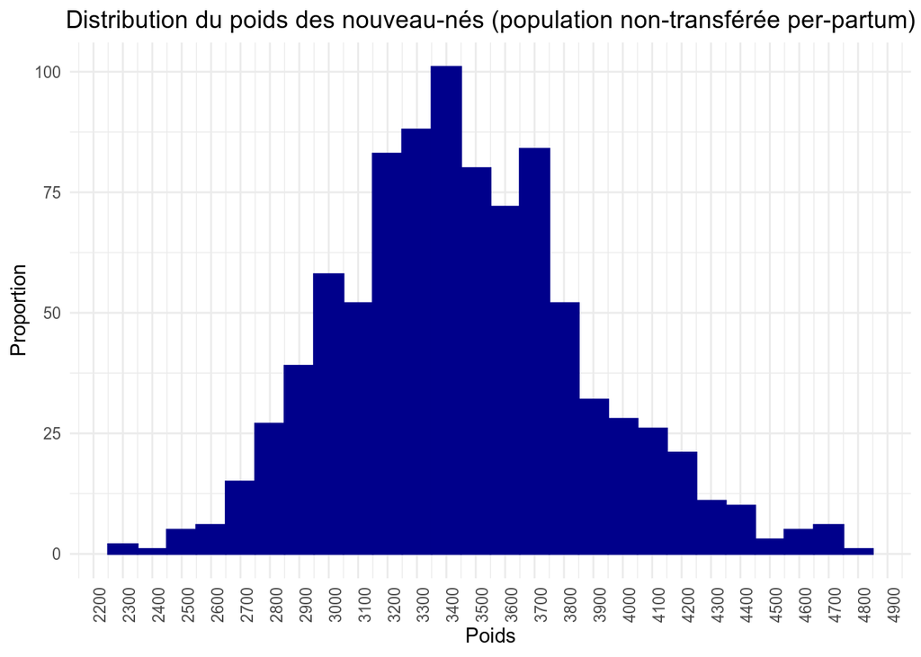

## 7.2 Score d’Apgar

### 7.2.1 Distributions à 1 / 5 / 10 minutes

| Apgar | Score moyen | Score minimal | Score maximal | Écart-type |
| --- | --- | --- | --- | --- |
| 1 min | 9.70 | 1 | 10 | 0.91 |
| 5 min | 9.93 | 6 | 10 | 0.36 |
| 10 min | 9.99 | 8 | 10 | 0.13 |

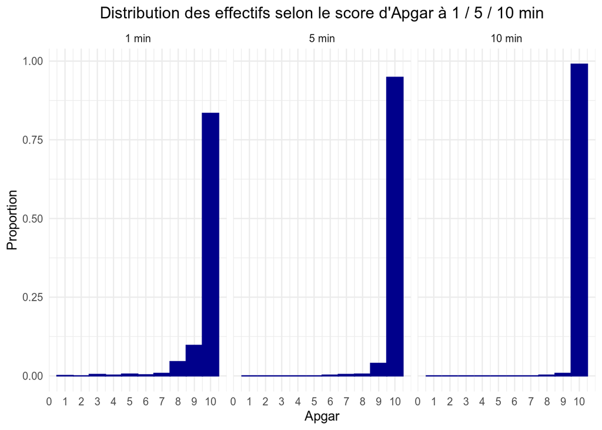

### 7.2.2 Populations ayant un score d’Apgar supérieur aux seuils 7 / 9 / 10

| Apgar | Score | Nombre | Proportion |
| --- | --- | --- | --- |
| 5 min | Score >= 7 | 907 | 99.78 % |
| 5 min | Score >= 9 | 898 | 98.79 % |
| 5 min | Score = 10 | 862 | 94.83 % |
| 10 min | Score >= 7 | 909 | 100 % |
| 10 min | Score >= 9 | 907 | 99.78 % |
| 10 min | Score = 10 | 900 | 99.01 % |

### 7.2.3 Lien entre score d’Apgar et durée d’explusion / poids / parité / âge de la mère / auscultation

Le score d’Apgar étudié est la moyenne des scores à 1 / 5 / 10 min. On construit le modèle linéaire suivant :

```
##
## Call:
## lm(formula = Score ~ rcf + duree_expulsion + poids + parite,
##     data = don_reg_agpar)
##
## Coefficients:
##                                 (Intercept)
##                                 10.06261105
## rcfAuscultation intermittente et monitoring
##                                 -0.06815658
##                               rcfMonitoring
##                                  0.13134927
##                       rcfPas d'auscultation
##                                  0.05140815
##                             duree_expulsion
##                                 -0.00154042
##                                       poids
##                                 -0.00004194
##                                      parite
##                                 -0.01018602
```

```
## Analysis of Variance Table
##
## Response: Score
##                  Df  Sum Sq Mean Sq F value  Pr(>F)
## rcf               3   1.579 0.52622  2.9941 0.03007 *
## duree_expulsion   1   0.665 0.66542  3.7861 0.05200 .
## poids             1   0.336 0.33573  1.9102 0.16728
## parite            1   0.127 0.12659  0.7203 0.39628
## Residuals       887 155.893 0.17575
## ---
## Signif. codes:  0 '***' 0.001 '**' 0.01 '*' 0.05 '.' 0.1 ' ' 1
```

### 7.2.4 Lien entre (score d’Apgar < 7 à une minute) et auscultation

|  | Auscultation intermittente | Auscultation intermittente et monitoring | Monitoring | Pas d’auscultation |
| --- | --- | --- | --- | --- |
| apgar_1_inf_7 | 9 | 5 | 0 | 1 |
| apgar_1_superieur_egal_7 | 583 | 108 | 10 | 193 |

Il n’y a pas assez de cas pour prendre en considération les modalités ‘Monitoring’ et ‘Pas d’auscultation’. On réalise un test d’indépendance sur les données ci-dessous :

|  | Auscultation intermittente | Auscultation intermittente et monitoring |
| --- | --- | --- |
| apgar_1_inf_7 | 9 | 5 |
| apgar_1_superieur_egal_7 | 583 | 108 |

```
##
##  Pearson's Chi-squared test with Yates' continuity correction
##
## data:  .
## X-squared = 2.7558, df = 1, p-value = 0.0969
```

On ne rejette pas l’hypothèse d’indépendance au seuil de 5%. Il n’y a pas de lien statistique entre auscultation et Apgar à 1 min < 7 d’après les données considérées.

## 7.3 État du bébé

### 7.3.1 Distribution

| État du bébé | Nombre | Proportion |
| --- | --- | --- |
| Vivant | 909 | 100 % |

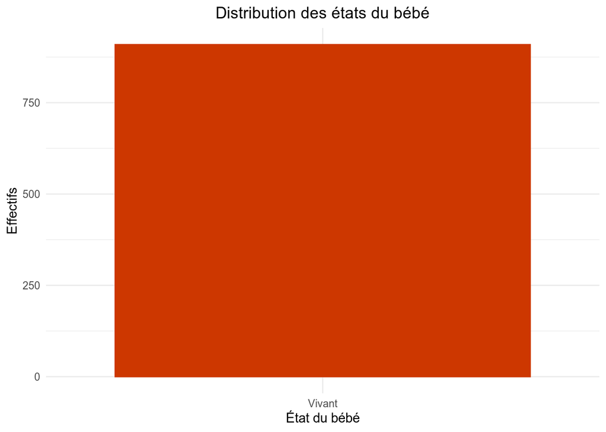

## 7.4 Réanimation bébé

| Réanimation du bébé | Nombre | Proportion |
| --- | --- | --- |
| Aucune | 866 | 95.27 % |
| Aspiration / Stimulation | 36 | 3.96 % |
| Ventilation | 7 | 0.77 % |

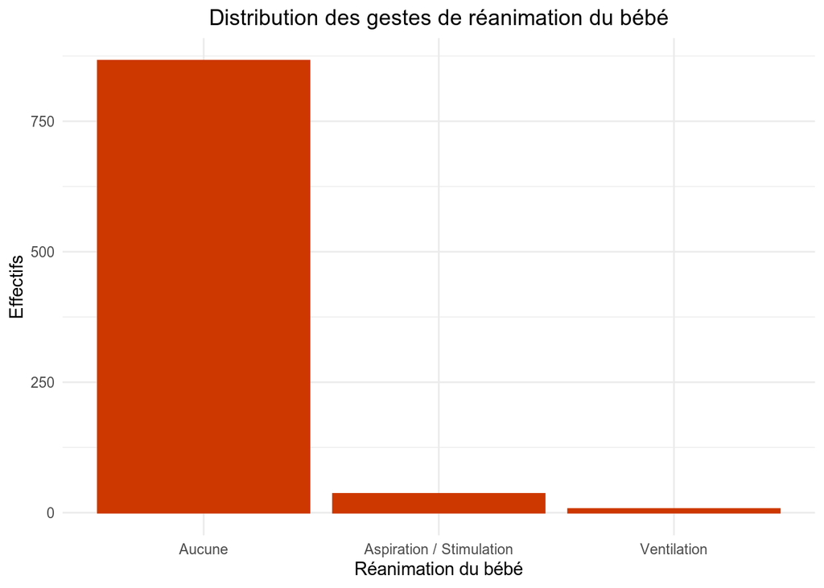

### 7.4.1 Liaison entre réanimation du bébé et scores d’Apgar

On effectue une régression logistique où la variable à expliquer est la réanimation du bébé (1 : réanimation / 0 : pas de réanimation), et les variables explicatives sont les trois scores d’Apgar à 1, 5 et 10 min.

```
##
## Call:
## glm(formula = rea_bebe ~ apgar_1 + apgar_5 + apgar_10, family = "binomial",
##     data = don_rea_apgar)
##
## Deviance Residuals:
##     Min       1Q   Median       3Q      Max
## -2.5936  -0.1275  -0.1275  -0.1275   3.1035
##
## Coefficients:
##             Estimate Std. Error z value        Pr(>|z|)
## (Intercept)  41.7252    12.7787   3.265         0.00109 **
## apgar_1      -1.6272     0.2399  -6.782 0.0000000000118 ***
## apgar_5      -0.8842     0.4822  -1.834         0.06671 .
## apgar_10     -2.1419     1.3202  -1.622         0.10472
## ---
## Signif. codes:  0 '***' 0.001 '**' 0.01 '*' 0.05 '.' 0.1 ' ' 1
##
## (Dispersion parameter for binomial family taken to be 1)
##
##     Null deviance: 346.33  on 908  degrees of freedom
## Residual deviance: 160.92  on 905  degrees of freedom
## AIC: 168.92
##
## Number of Fisher Scoring iterations: 7
```

Les résidus présentent une excellente symétrie. On effectue un test de vraissemblance (LRT) pour estimer la significativité statistiques des variables explicatives car ce test est plus robuste que le test de Wald dont les résultats sont disponibles ci-dessus.

```
## Analysis of Deviance Table
##
## Model: binomial, link: logit
##
## Response: rea_bebe
##
## Terms added sequentially (first to last)
##
##
##          Df Deviance Resid. Df Resid. Dev  Pr(>Chi)
## NULL                       908     346.33
## apgar_1   1  175.679       907     170.65 < 2.2e-16 ***
## apgar_5   1    6.655       906     164.00  0.009888 **
## apgar_10  1    3.079       905     160.92  0.079287 .
## ---
## Signif. codes:  0 '***' 0.001 '**' 0.01 '*' 0.05 '.' 0.1 ' ' 1
```

D’après le test LRT, le score d’Apgar à une minute est extrêmement significatif dans la modélisation de la variable binaire de réanimation du bébé par une régression logistique. Par ailleurs l’estimation du coefficient associé à cet variable a une valeur importante. Les scores d’Apgar à 5 et 10 minutes sont statistiquement significatifs aux seuils de 5% et 10% respectivement, c’est-à-dire beaucoup moins que le score d’Apgar à une minute. A noter que leur coefficient sont non-négligeables.

## 7.5 Type d’alimentation

| Alimentation du bébé | Nombre | Proportion |
| --- | --- | --- |
| Allaitement maternel | 758 | 83.39 % |
| Têtée précoce | 148 | 16.28 % |
| Allaitement Artificiel | 2 | 0.22 % |
| Allaitement mixte | 1 | 0.11 % |

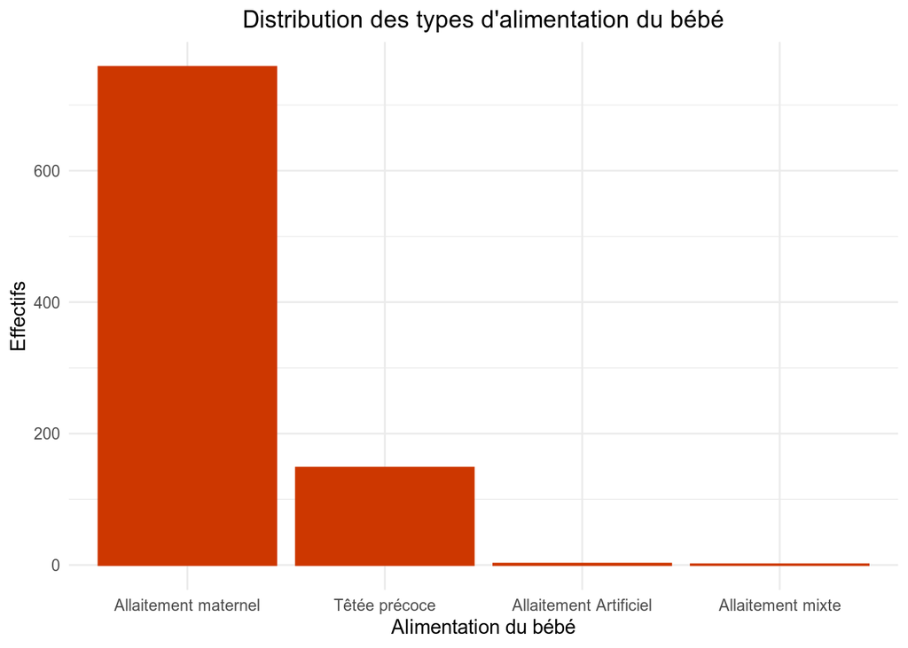

# 8 Transfert post-partum maternel pour les femmes ayant accouché à domicile

## 8.1 Effectifs par type de transfert post-partum maternel

| Type de transfert post-partum maternel | Nombre | Proportion |
| --- | --- | --- |
| Hémorragie du post partum | 11 | 78.57 % |
| Complications périnéales | 1 | 7.14 % |
| extériorisation d’un polype rectal de 7cm de diamètre avec les efforts expusifs | 1 | 7.14 % |
| Rétention placentaire, délivrance incomplète | 1 | 7.14 % |

## 8.2 Lien entre Transfert post-partum maternel et Durée d’expulsion / Poids / Parité / Âge

On effectue une régression logistique où la variable à expliquer est le transfert post-partum maternel (1 : transfert / 0 : pas de transfert), et les variables explicatives sont les suivantes : Durée d’expulsion / Poids / Parité / Âge. Il faut noter que les données sont très déséquilibrées, avec seulement 14 transfert post-partum maternels pour 916 mères non-transférées. Cette situation a des conséquences négatives sur la fiabilité du modèle construit ci-dessous.

```
##
## Call:
## glm(formula = transfert_post_partum_maternel ~ duree_expulsion +
##     poids + parite + age_mere, family = "binomial", data = don_tppm_)
##
## Deviance Residuals:
##     Min       1Q   Median       3Q      Max
## -0.4014  -0.2005  -0.1479  -0.0804   3.4328
##
## Coefficients:
##                   Estimate Std. Error z value Pr(>|z|)
## (Intercept)     -3.0336426  2.8662322  -1.058  0.28987
## duree_expulsion -0.0106119  0.0150530  -0.705  0.48083
## poids            0.0005418  0.0006373   0.850  0.39530
## parite          -1.3283831  0.5063960  -2.623  0.00871 **
## age_mere        -0.0151604  0.0638759  -0.237  0.81239
## ---
## Signif. codes:  0 '***' 0.001 '**' 0.01 '*' 0.05 '.' 0.1 ' ' 1
##
## (Dispersion parameter for binomial family taken to be 1)
##
##     Null deviance: 145.37  on 932  degrees of freedom
## Residual deviance: 133.34  on 928  degrees of freedom
##   (1 observation deleted due to missingness)
## AIC: 143.34
##
## Number of Fisher Scoring iterations: 8
```

Les résidus présentent une symétrie correcte. On effectue un test de vraissemblance (LRT) pour estimer la significativité statistiques des variables explicatives car ce test est plus robuste que le test de Wald dont les résultats sont disponibles ci-dessus.

```
## Analysis of Deviance Table
##
## Model: binomial, link: logit
##
## Response: transfert_post_partum_maternel
##
## Terms added sequentially (first to last)
##
##
##                 Df Deviance Resid. Df Resid. Dev  Pr(>Chi)
## NULL                              932     145.37
## duree_expulsion  1   0.4481       931     144.92 0.5032602
## poids            1   0.0468       930     144.88 0.8287503
## parite           1  11.4783       929     133.40 0.0007041 ***
## age_mere         1   0.0563       928     133.34 0.8123645
## ---
## Signif. codes:  0 '***' 0.001 '**' 0.01 '*' 0.05 '.' 0.1 ' ' 1
```

D’après le test LRT, la parité est statistiquement significative au seuil de 1%. Une grande partié diminue la probabilité de transfert post partum maternel.

# 9 Transfert post-partum néonatal pour les femmes ayant accouché à domicile

## 9.1 Effectifs par type de transfert post-partum néonatal

| Type de transfert post-partum néonatal | Nombre | Proportion |
| --- | --- | --- |
| Anomalies de l’examen de naissance nécessitant une évaluation ( malformation … ) | 2 | 18.18 % |
| Détresse Respiratoire | 2 | 18.18 % |
| Oui | 2 | 18.18 % |
| avc | 1 | 9.09 % |
| Détresse Respiratoire, double circulaire serré … DR | 1 | 9.09 % |
| Hypotrophie < 2500 g, hypothermie, glycémie normale | 1 | 9.09 % |
| stridor important | 1 | 9.09 % |
| Surveillance suite réa | 1 | 9.09 % |

## 9.2 Lien entre Transfert post-partum néonatal et Durée d’expulsion / Poids / Parité / Âge

```
##
## Call:
## glm(formula = transfert_post_partum_neonatal ~ duree_expulsion +
##     poids + parite + age_mere, family = "binomial", data = don_tppb_)
##
## Deviance Residuals:
##     Min       1Q   Median       3Q      Max
## -0.2950  -0.1730  -0.1477  -0.1251   3.1288
##
## Coefficients:
##                   Estimate Std. Error z value Pr(>|z|)
## (Intercept)     -5.2407326  3.4493849  -1.519    0.129
## duree_expulsion  0.0024441  0.0118730   0.206    0.837
## poids           -0.0002067  0.0007523  -0.275    0.784
## parite          -0.3913320  0.3663084  -1.068    0.285
## age_mere         0.0699505  0.0710233   0.985    0.325
##
## (Dispersion parameter for binomial family taken to be 1)
##
##     Null deviance: 119.56  on 932  degrees of freedom
## Residual deviance: 117.23  on 928  degrees of freedom
##   (1 observation deleted due to missingness)
## AIC: 127.23
##
## Number of Fisher Scoring iterations: 7
```

Les résidus présentent une symétrie correcte. On effectue un test de vraissemblance (LRT) pour estimer la significativité statistiques des variables explicatives car ce test est plus robuste que le test de Wald dont les résultats sont disponibles ci-dessus.

```
## Analysis of Deviance Table
##
## Model: binomial, link: logit
##
## Response: transfert_post_partum_neonatal
##
## Terms added sequentially (first to last)
##
##
##                 Df Deviance Resid. Df Resid. Dev Pr(>Chi)
## NULL                              932     119.56
## duree_expulsion  1  0.33576       931     119.22   0.5623
## poids            1  0.21754       930     119.01   0.6409
## parite           1  0.80479       929     118.20   0.3697
## age_mere         1  0.97286       928     117.23   0.3240
```

# 10 Suites de couche

## 10.1 Effectifs par type de difficultés

| Suites de couches | Nombre | Proportion |
| --- | --- | --- |
| RAS | 798 | 87.79 % |
| Difficultés mère | 44 | 4.84 % |
| Difficultés bébé | 40 | 4.4 % |
| Difficultés mère, Difficultés bébé | 27 | 2.97 % |

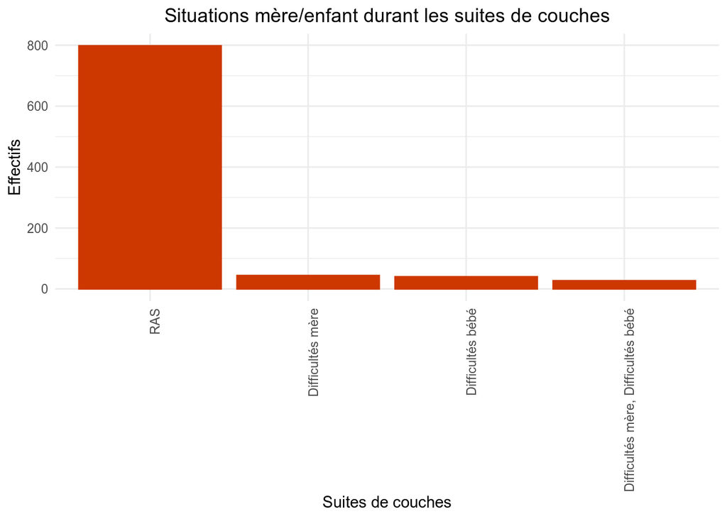

## 10.2 Hospitalisation dans les 8 jours suivant l’accouchement (femmes non-transférées dans le cadre de l’accouchement)

### 10.2.1 Mère

| Hospitalisation Mère | Nombre | Proportion |
| --- | --- | --- |
| Non | 894 | 98.35 % |
| Hospitalisation du bébé | 6 | 0.66 % |
| Endométrite | 4 | 0.44 % |
| Autre | 3 | 0.33 % |
| Hémorragie secondaire | 2 | 0.22 % |

### 10.2.2 Bébé (femmes non-transférées dans le cadre de l’accouchement)

| Hospitalisation Bébé | Nombre | Proportion |
| --- | --- | --- |
| Non | 883 | 97.14 % |
| Suspicion d’infection | 7 | 0.77 % |
| Autre | 6 | 0.66 % |
| Déshydratation | 6 | 0.66 % |
| Hospitalisation de la mère | 4 | 0.44 % |
| Ictère | 3 | 0.33 % |

# 11 Pratiques des sages-femmes

## 11.1 Nombre de touchers vaginaux

| Nombre moyen | Nombre minimal | Nombre maximal | Écart-type |
| --- | --- | --- | --- |
| 1.67 | 0 | 15 | 1.91 |

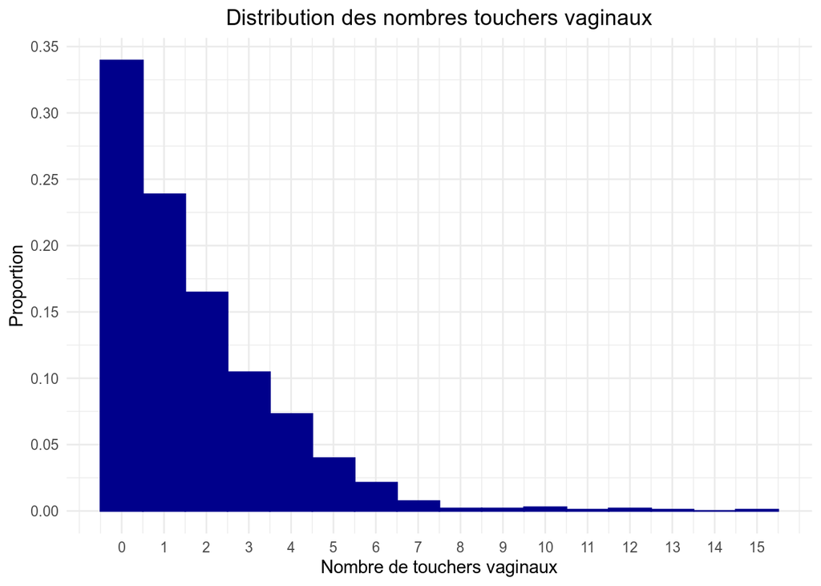

367 femmes n’ont eu aucun toucher vaginal, soit 33.95 % de la population pour laquelle la donnée est disponible.

# 12 Auscultation foetale

## 12.1 Effectifs

| Surveillance RCF | Nombre | Proportion |
| --- | --- | --- |
| Auscultation intermittente | 702 | 64.94 % |
| Pas d’auscultation | 210 | 19.43 % |
| Auscultation intermittente et monitoring | 153 | 14.15 % |
| Monitoring | 15 | 1.39 % |
| Auscultation continue | 1 | 0.09 % |

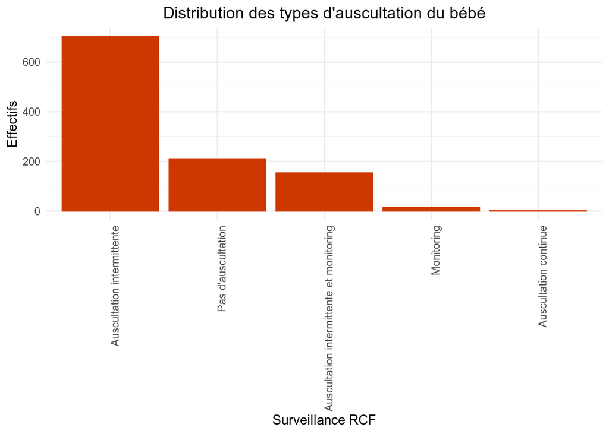

## 12.2 Tableau croisé d’effectifs Auscultation foetale / Transfert post-partum du bébé

| Auscultation | Transfert post-partum bébé | Nombre | Proportion |
| --- | --- | --- | --- |
| Auscultation continue | Non | 1 | 100 % |
| Auscultation intermittente | Non | 694 | 98.86 % |
| Auscultation intermittente | Oui | 8 | 1.14 % |
| Auscultation intermittente et monitoring | Non | 152 | 99.35 % |
| Auscultation intermittente et monitoring | Oui | 1 | 0.65 % |
| Monitoring | Non | 15 | 100 % |
| Pas d’auscultation | Non | 208 | 99.05 % |
| Pas d’auscultation | Oui | 2 | 0.95 % |

# 13 Soulagement de la douleur

| Types de soulagement de la douleur | Nombre | Proportion |
| --- | --- | --- |
| Autonomie | 650 | 50.08 % |
| NA | 407 | 31.36 % |
| Bain | 174 | 13.41 % |
| Massages | 28 | 2.16 % |
| Homéopathie/aromathérapie | 25 | 1.93 % |
| Sophrologie / Hypnose | 8 | 0.62 % |
| Acupuncture | 3 | 0.23 % |
| Mobilisation | 3 | 0.23 % |

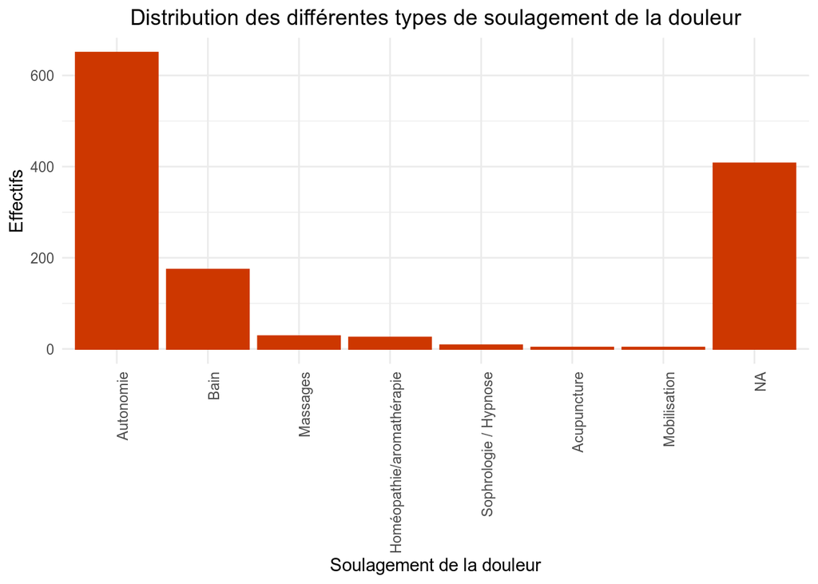

# 14 Soins du périnée

## 14.1 Effectifs

| Types de soins du périnée | Nombre | Proportion |
| --- | --- | --- |
| Aucun | 501 | 38.6 % |
| NA | 360 | 27.73 % |
| Soins locaux ( argile, calendula …) | 328 | 25.27 % |
| Suture | 109 | 8.4 % |

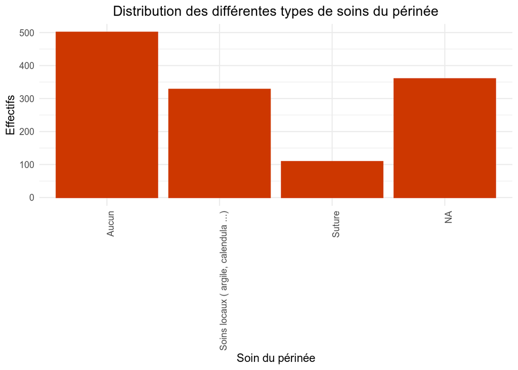

## 14.2 Soins du périnée & état du périnée

| État du périnée | Soin du périnée | Nombre | Proportion |
| --- | --- | --- | --- |
| Intact | Aucun | 464 | 75.08 % |
| Intact | Soins locaux ( argile, calendula …) | 153 | 24.76 % |
| Intact | Suture | 1 | 0.16 % |
| 1° degré : peau, muqueuse vaginale | Aucun | 35 | 13.73 % |
| 1° degré : peau, muqueuse vaginale | Soins locaux ( argile, calendula …) | 165 | 64.71 % |
| 1° degré : peau, muqueuse vaginale | Suture | 55 | 21.57 % |
| 2° degré : peau, muqueuse vaginale, muscles périnéaux | Aucun | 2 | 3.28 % |
| 2° degré : peau, muqueuse vaginale, muscles périnéaux | Soins locaux ( argile, calendula …) | 10 | 16.39 % |
| 2° degré : peau, muqueuse vaginale, muscles périnéaux | Suture | 49 | 80.33 % |
| 3° degré : périnée complet non-compliqué | Suture | 1 | 100 % |
| Épisiotomie | Suture | 3 | 100 % |

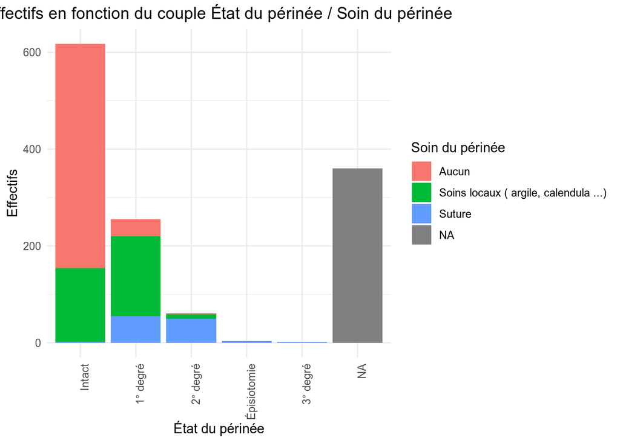

# 15 Données sur les sages-femmes et la maternité

## 15.1 Temps de présence de la sage-femme

| Durée moyenne (h) | Durée minimale (h) | Durée maximale (h) | Écart-type (h) |
| --- | --- | --- | --- |
| 6.23 | 0 | 40 | 4.13 |

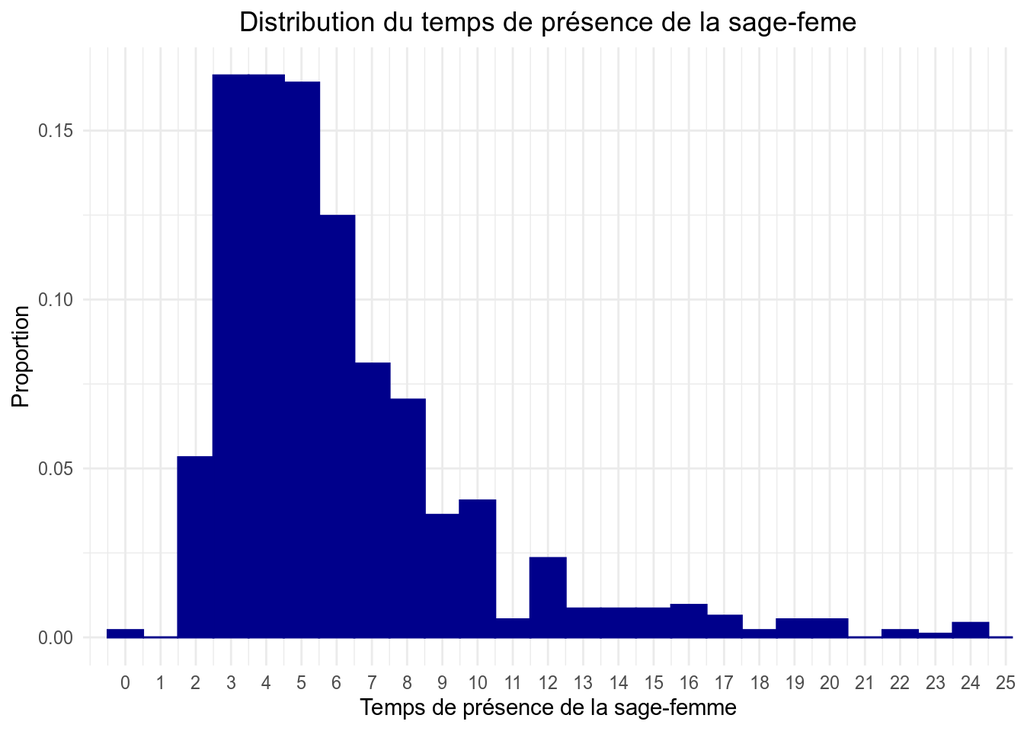

## 15.2 Distance entre le domicile de la mère et la sage-femme

| Distance moyenne (km) | Distance minimale (km) | Distance maximale (km) | Écart-type (km) |
| --- | --- | --- | --- |
| 42.28 | 1 | 369 | 36.96 |

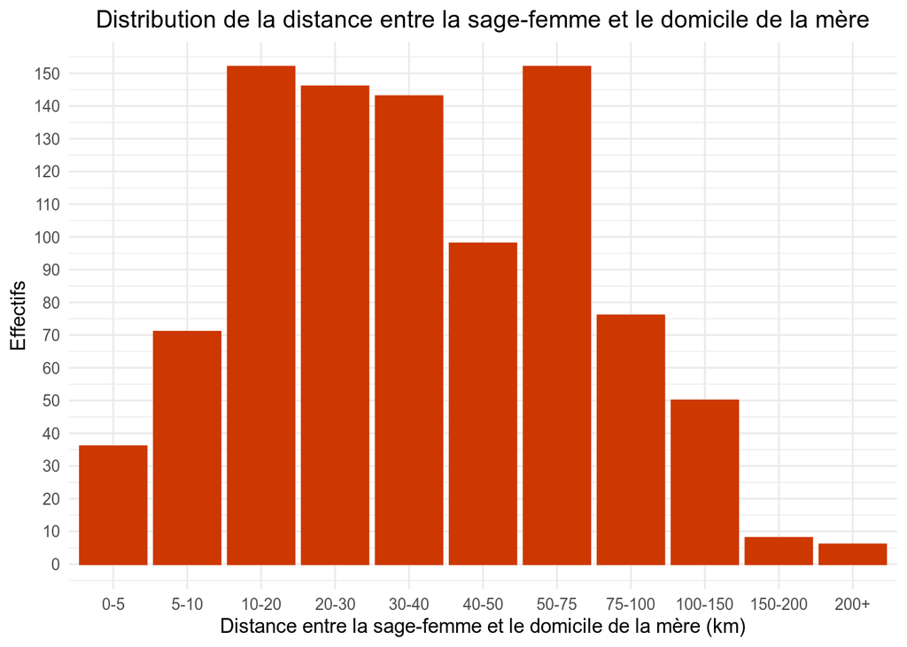

## 15.3 Distance entre le domicile de la mère et la maternité

| Distance moyenne (km) | Distance minimale (km) | Distance maximale (km) | Écart-type (km) |
| --- | --- | --- | --- |
| 19.57 | 1 | 78 | 12.98 |

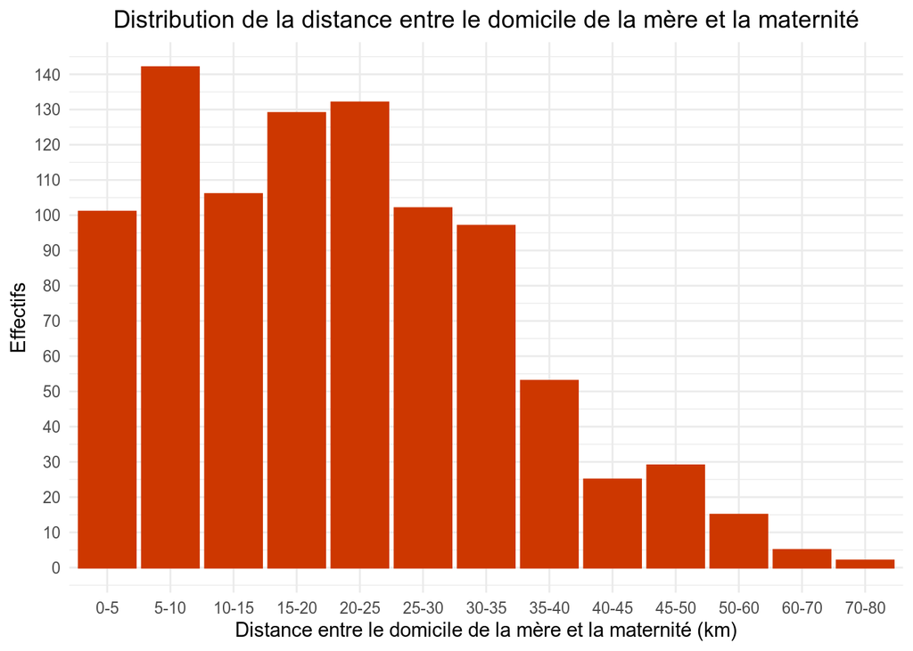

35.18 % des femmes habitent à plus de 45 km de leur sage-femme, alors que seulement 5.44 % des femmes habitent à plus de 45 km de la maternité.

## 15.4 Deuxième sage-femme

| Deuxième sage-femme | Nombre | Proportion |
| --- | --- | --- |
| Non : pas prévue | 772 | 82.3 % |
| Oui | 145 | 15.46 % |
| Non : pas eu le temps d’arriver ou finalement pas nécessaire | 21 | 2.24 % |

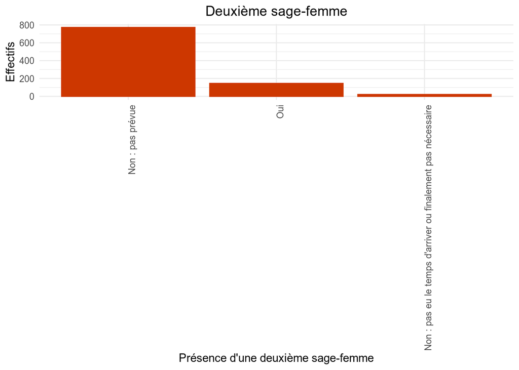

# 16 Comparaison d’incidences 2019 vs 2020

On effectue un test d’égalité de proportions pour comparer l’incidence de divers événements entre l’année 2019 et l’année 2020. On utilise le test uniquement lorsque les conditions d’applications sont réunies, à savoir des effectifs théoriques marginaux supérieurs ou égaux à 5. Ce test utilise la statistique du $\chi²$ de Pearson, implémenté dans la fonction *prop.test()*. Le niveau de confiance choisi est de 5%.  
Dans le cas où les hypothèses du test d’égalité de proportions ne sont pas satisfaites, les proportions observées sont quand même communiquées.

## 16.1 État périnéal

### 16.1.1 Intact

```
##
##  2-sample test for equality of proportions with continuity correction
##
## data:  c(p1 * 913/100, p2 * 1081/100) out of c(913, 1081)
## X-squared = 0.42759, df = 1, p-value = 0.5132
## alternative hypothesis: two.sided
## 95 percent confidence interval:
##  -0.05797262  0.02797262
## sample estimates:
## prop 1 prop 2
##  0.645  0.660
```

La différence de proportions entre 2019 et 2020 ne permet pas de rejeter l’hypothèse d’égalité au seuil de 5%.

### 16.1.2 Déchirure simple (degré 1 et 2)

```
##
##  2-sample test for equality of proportions with continuity correction
##
## data:  c(p1 * 913/100, p2 * 1081/100) out of c(913, 1081)
## X-squared = 4.3057e-29, df = 1, p-value = 1
## alternative hypothesis: two.sided
## 95 percent confidence interval:
##  -0.04162829  0.04362829
## sample estimates:
## prop 1 prop 2
##  0.337  0.336
```

La différence de proportions entre 2019 et 2020 ne permet pas de rejeter l’hypothèse d’égalité au seuil de 5%.

### 16.1.3 Déchirure complète

Les proportions semblent stables, passant de 0.0 % en 2019 à 0.1 % en 2020.

### 16.1.4 Déchirure complète compliquée

Les proportions semblent stables, passant de 0.2 % en 2019 à 0.0 % en 2020.

### 16.1.5 Épisiotomie

Les proportions sont identiques en 2019 et en 2020 (0.3 %). Les conditions du test d’égalité des proportions ne sont cependant pas réunies pour affirmer que cette égalité est statistiquement représentative.

## 16.2 Délivrance

### 16.2.1 Administration prophylactique d’ocytocine

Les proportions semblent stables, passant de 0.4 % en 2019 à 0.5 % en 2020.

### 16.2.2 Complète

```
##
##  2-sample test for equality of proportions with continuity correction
##
## data:  c(p1 * 913/100, p2 * 1081/100) out of c(913, 1081)
## X-squared = 5.2359, df = 1, p-value = 0.02213
## alternative hypothesis: two.sided
## 95 percent confidence interval:
##  -0.032066353 -0.001933647
## sample estimates:
## prop 1 prop 2
##  0.966  0.983
```

L’hypothèse d’égalité des proportions est **rejetée** au seuil de 5%. L’augmentation du taux de délivrance complète est statistiquement significative au seuil de 5%.

### 16.2.3 Incomplète

```
##
##  2-sample test for equality of proportions without continuity
##  correction
##
## data:  c(p1 * 913/100, p2 * 1081/100) out of c(913, 1081)
## X-squared = 4.7288e-31, df = 1, p-value = 1
## alternative hypothesis: two.sided
## 95 percent confidence interval:
##  -0.007848077  0.007848077
## sample estimates:
## prop 1 prop 2
##  0.008  0.008
```

Les proportions sont identiques et les conditions d’applications du test d’égalité de proportions sont réunies. Par conséquent, l’hypothèse d’égalité des proportions ne peut être rejetée.

### 16.2.4 Artificielle

```
##
##  2-sample test for equality of proportions with continuity correction
##
## data:  c(p1 * 913/100, p2 * 1081/100) out of c(913, 1081)
## X-squared = 3.8217, df = 1, p-value = 0.05059
## alternative hypothesis: two.sided
## 95 percent confidence interval:
##  -0.0003609467  0.0203609467
## sample estimates:
## prop 1 prop 2
##  0.016  0.006
```

La différence de proportions entre 2019 et 2020 ne permet pas de rejeter l’hypothèse d’égalité. La p-value est néanmoins très proche du seuil fixé à 5%.

## 16.3 Hémorragie du post-partum

### 16.3.1 HPP sévère > 1000ml

```
##
##  2-sample test for equality of proportions with continuity correction
##
## data:  c(p1 * 913/100, p2 * 1081/100) out of c(913, 1081)
## X-squared = 1.0298, df = 1, p-value = 0.3102
## alternative hypothesis: two.sided
## 95 percent confidence interval:
##  -0.013501052  0.003501052
## sample estimates:
## prop 1 prop 2
##  0.005  0.010
```

L’hypothèse d’égalité des proportions 2019/2020 n’est pas rejetée au seuil de 5%.

## 16.4 Mortalité maternelle

Aucune femme n’est décédée dans les échantillons 2019 et 2020.

## 16.5 État de l’enfant

La totalité des enfants observés en 2019 et en 2020 sont nés vivants (aucun décès néonatal, aucun mort-né). Par ailleurs, aucun enfant n’avait un score d’Apgar strictement inférieur à 7 en 2019, contre 0.4 % en 2020. Malgré cette augmentation, c’est un phénomène qui semble marginal.

## 16.6 Allaitement

```
##
##  2-sample test for equality of proportions with continuity correction
##
## data:  c(p1 * 913/100, p2 * 1081/100) out of c(913, 1081)
## X-squared = 13.733, df = 1, p-value = 0.0002107
## alternative hypothesis: two.sided
## 95 percent confidence interval:
##  -0.033156044 -0.008843956
## sample estimates:
## prop 1 prop 2
##  0.974  0.995
```

Le test **rejette** clairement l’hypothèse d’égalité des proportions au seuil de 5%, ce qui suggère une augmentation significative de la proportion des femmes ayant l’allaitement comme mode d’alimentation entre 2019 et 2020.

## 16.7 Transferts per partum

```
##
##  2-sample test for equality of proportions with continuity correction
##
## data:  c(p1 * 913/100, p2 * 1081/100) out of c(913, 1081)
## X-squared = 0.27599, df = 1, p-value = 0.5993
## alternative hypothesis: two.sided
## 95 percent confidence interval:
##  -0.03974325  0.02174325
## sample estimates:
## prop 1 prop 2
##  0.127  0.136
```

On ne rejette pas l’hypothèse d’égalité des proportions entre 2019 et 2020 pour les transferts per partum.

## 16.8 Transferts postpartum immédiats - Mère

```
##
##  2-sample test for equality of proportions with continuity correction
##
## data:  c(p1 * 913/100, p2 * 1081/100) out of c(913, 1081)
## X-squared = 3.8269, df = 1, p-value = 0.05044
## alternative hypothesis: two.sided
## 95 percent confidence interval:
##  -0.0003449879  0.0263449879
## sample estimates:
## prop 1 prop 2
##  0.026  0.013
```

On ne rejette pas l’hypothèse d’égalité des proportions entre 2019 et 2020 pour les transferts postpartum immédiats de la mère.

## 16.9 Transferts postpartum immédiats - Bébé

```
##
##  2-sample test for equality of proportions with continuity correction
##
## data:  c(p1 * 913/100, p2 * 1081/100) out of c(913, 1081)
## X-squared = 0.060474, df = 1, p-value = 0.8057
## alternative hypothesis: two.sided
## 95 percent confidence interval:
##  -0.010816659  0.006816659
## sample estimates:
## prop 1 prop 2
##  0.007  0.009
```

On ne rejette pas l’hypothèse d’égalité des proportions entre 2019 et 2020 pour les transferts postpartum immédiats du bébé.

## 16.10 Conclusion

Les tests d’égalité de proportions ci-dessus - ou la simple comparaison des proportions observées lorsque les conditions d’application ne sont pas réunies - invitent à penser que les indicateurs étudiés ont été stables entre les années 2019 et 2020. Les proportions de délivrance complète et de femmes ayant choisi d’allaiter font exception. Pour ces deux indicateurs, les proportions relevées suggèrent une augmentation significative entre 2019 et 2020.